# Logistic Regression Demo Notebook

#### Read Brazilian Beer Data

Recall the beer data contains the liters of beer consumed as a function of precip, maximum temperature, and weekend. Now consider modeling whether the day is a weekend.

```r
library(readr)
library(dplyr)
library(ggplot2)
library(gridExtra)
library(arm)
library(rbin)
beer <- read_csv("http://math.montana.edu/ahoegh/Data/Brazil_cerveja.csv")
beer <- beer %>% mutate(weekend_fact = as.factor(weekend))
```

#### Data Viz

It seems likely that consumption patterns would change depending on whether the day was a weekend. The data viz also suggest this is the case.

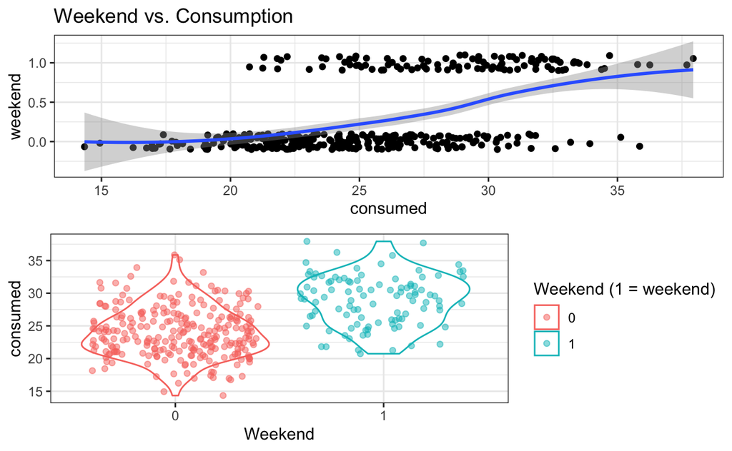

```r
consumption_fig <- beer %>% ggplot(aes(y = weekend, x = consumed)) + geom_jitter(height = .1) + geom_smooth(method = "loess") + ggtitle('Weekend vs. Consumption') + theme_bw()
consumption_violin <- beer %>% ggplot(aes(x = weekend_fact, y = consumed, color = weekend_fact)) + geom_violin() + geom_jitter( alpha = .5) + labs(color = "Weekend (1 = weekend)") + theme_bw() + xlab("Weekend")

grid.arrange(consumption_fig, consumption_violin, nrow = 2, ncol = 1)
```

It does not seem plausible that the weather would be different on the weekends. This is seen in the figures for maximum temperature.

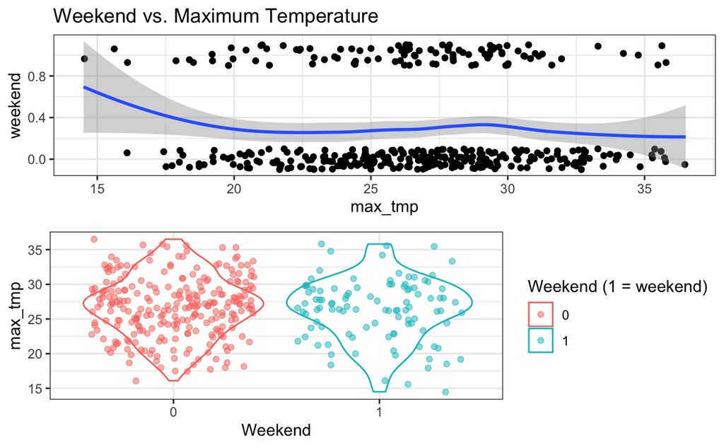

```r
temp_fig <- beer %>% ggplot(aes(y = weekend, x = max_tmp)) + geom_jitter(height = .1) + geom_smooth(method = "loess") + ggtitle('Weekend vs. Maximum Temperature') + theme_bw()
temp_violin <- beer %>% ggplot(aes(x = weekend_fact, y = max_tmp, color = weekend_fact)) + geom_violin() + geom_jitter( alpha = .5) + labs(color = "Weekend (1 = weekend)") + theme_bw() + xlab("Weekend")

grid.arrange(temp_fig, temp_violin, nrow = 2, ncol = 1)
```

#### Fitting Model

Consider two models: what is the difference between these?

```r
glm_beer <- glm(weekend ~ consumed, data = beer)
display(glm_beer)
```

```
glm(formula = weekend ~ consumed, data = beer)
            coef.est coef.se
(Intercept) -1.04     0.12
consumed     0.05     0.00
---
  n = 365, k = 2
  residual deviance = 55.3, null deviance = 74.4 (difference = 19.0)
  overdispersion parameter = 0.2
  residual sd is sqrt(overdispersion) = 0.39
```

**This one treats the response as continuous and is actually just fitting a linear regression model.**

```r
glm_beer2 <- glm(weekend_fact ~consumed, data = beer, family = binomial)
display(glm_beer2)
```

```
glm(formula = weekend_fact ~ consumed, family = binomial, data = beer)
            coef.est coef.se
(Intercept) -9.32     1.03
consumed     0.32     0.04
---
  n = 365, k = 2
  residual deviance = 333.7, null deviance = 436.2 (difference = 102.5)
```

**This is logistic regression.** Before looking at model coefficients, lets take a look at the fitted model.

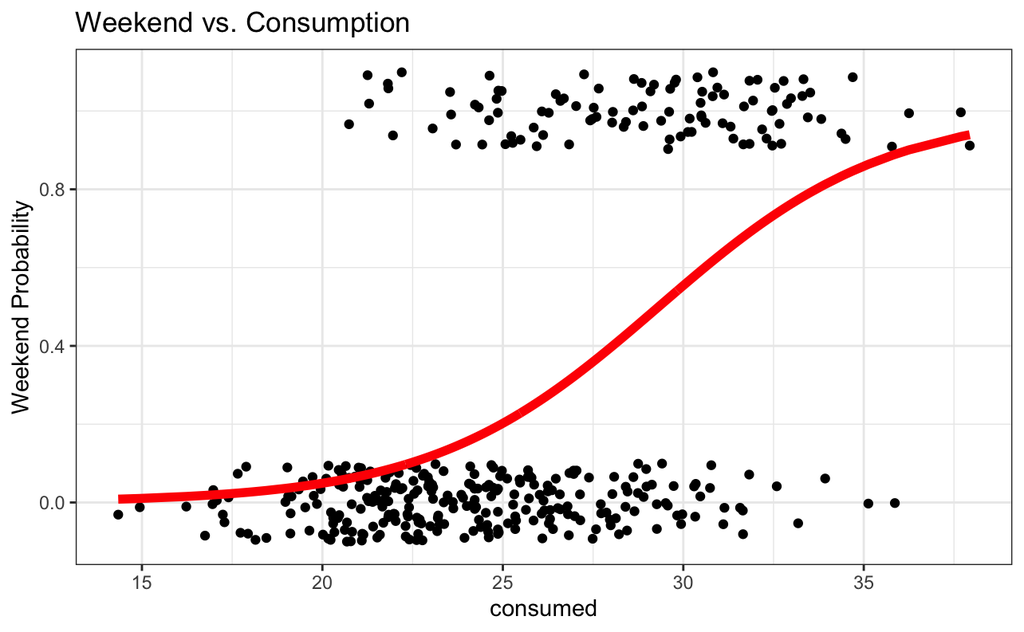

```r
beer <- beer %>% mutate(weekend_fitted = fitted(glm_beer2))

beer %>% ggplot(aes(y = weekend, x = consumed)) + geom_jitter(height = .1) +  ggtitle('Weekend vs. Consumption') + theme_bw() + geom_line(aes(y = weekend_fitted, x = consumed), col = 'red', lwd = 2) + ylab('Weekend Probability')
```

### Coefficient interpretations

```r
beer <- beer %>% mutate(scaled_consumed = scale(consumed))
glm_beer_scaled <- glm(weekend_fact ~scaled_consumed, data = beer, family = binomial)
beta_mean <- as.numeric(round(exp(coef(glm_beer_scaled)['scaled_consumed'])))
display(glm_beer_scaled)
```

```
glm(formula = weekend_fact ~ scaled_consumed, family = binomial,
    data = beer)
                coef.est coef.se
(Intercept)     -1.24     0.15
scaled_consumed  1.40     0.17
---
  n = 365, k = 2
  residual deviance = 333.7, null deviance = 436.2 (difference = 102.5)
```

**Intercept:** The intercept can be interpreted as the the logit scaled probability of success at the zero value of the other parameters.

In this case, the intercept can be interpreted as the probability of a weekend at the average consumption (25 liters) is $logit^{-1}$(-1.24) = 0.22.

**scaled_consumed:** All three intepretations are provided, but typically choose one.

*log odds:* there is evidence that the mean log odds for scaled consumption is positive (95% CI: 1.09, 1.74), suggesting that increased consumption results in a higher probability of the day being a weekend day.

*odds:* there is evidence that the mean odds for scaled consumption is greater than one (95% CI: 2.97, 5.69). In particular, with a one SD increase in consumption the odds of a weekend day increases by roughly 4.

*probability:* With a one sd increase from mean consumption the probability that the day is a weekend day increases from 0.22 to 0.54. Similarly for a one sd decrease from mean consumption, the probability that the day is a weekend day decreases from 0.22 to 0.07.

### Diagnostics

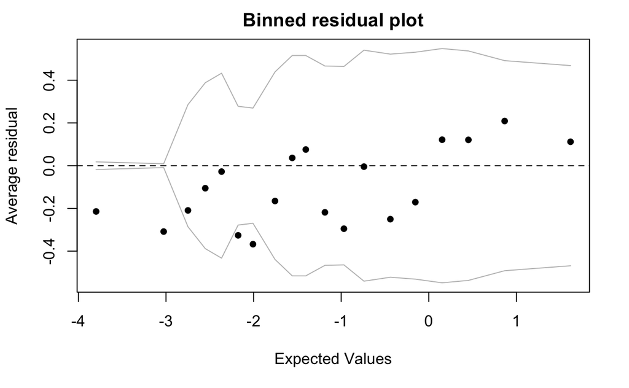

```r
binnedplot(predict(glm_beer_scaled), resid(glm_beer_scaled))
```

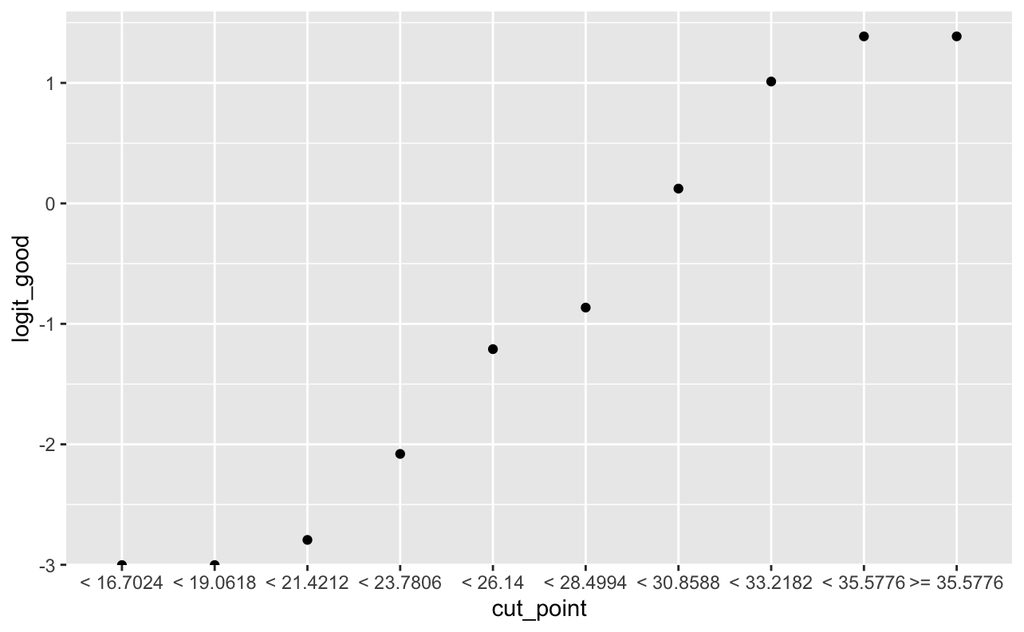

```r
bins <- rbin_equal_length(beer,weekend, consumed, bins = 10)$bins
bins <- bins %>% mutate(logit_good = logit(good_rate))
bins %>% ggplot(aes(y = logit_good, x = cut_point)) + geom_point() + geom_smooth(method = 'loess')
```

```r
beer <- beer %>% mutate(scaled_consumed_log = scale(log(consumed)),
                        scaled_consumed_sq = scaled_consumed^2,
                        scaled_consumed_cube = scaled_consumed^3)
glm_beer_scaled2 <- glm(weekend_fact ~scaled_consumed_log, data = beer, family = binomial)
display(glm_beer_scaled2)
```

```
glm(formula = weekend_fact ~ scaled_consumed_log, family = binomial,
    data = beer)
                    coef.est coef.se
(Intercept)         -1.31     0.16
scaled_consumed_log  1.49     0.18
---
  n = 365, k = 2
  residual deviance = 333.2, null deviance = 436.2 (difference = 103.0)
```

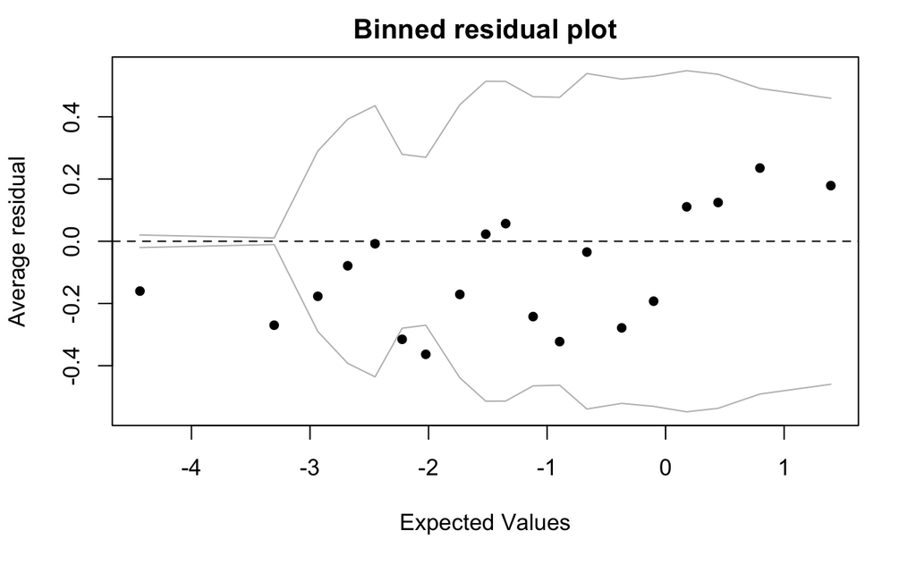

```r
binnedplot(predict(glm_beer_scaled2), resid(glm_beer_scaled2))
```

```r
glm_beer_scaled3 <- glm(weekend_fact ~scaled_consumed + scaled_consumed_sq, data = beer, family = binomial)
display(glm_beer_scaled3)
```

```
glm(formula = weekend_fact ~ scaled_consumed + scaled_consumed_sq,
    family = binomial, data = beer)
                   coef.est coef.se
(Intercept)        -1.19     0.17
scaled_consumed     1.48     0.22
scaled_consumed_sq -0.11     0.16
---
  n = 365, k = 3
  residual deviance = 333.3, null deviance = 436.2 (difference = 102.9)
```

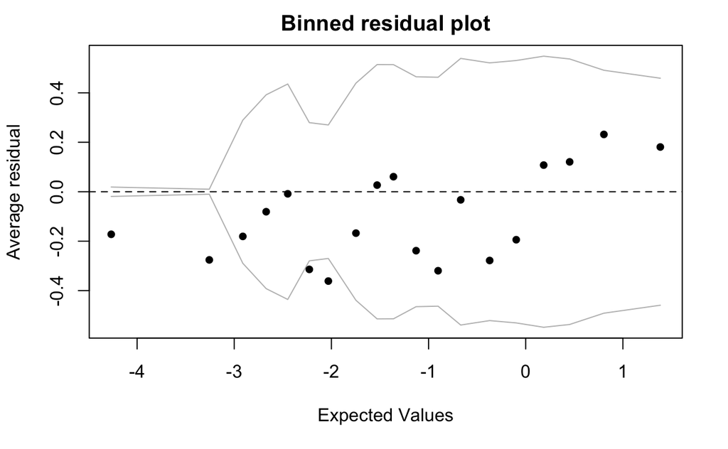

```r
binnedplot(predict(glm_beer_scaled3), resid(glm_beer_scaled3))
```

```r
glm_beer_scaled4 <- glm(weekend_fact ~scaled_consumed + scaled_consumed_sq + scaled_consumed_cube, data = beer, family = binomial)
display(glm_beer_scaled4)
```

```
glm(formula = weekend_fact ~ scaled_consumed + scaled_consumed_sq +
    scaled_consumed_cube, family = binomial, data = beer)
                     coef.est coef.se
(Intercept)          -1.16     0.19
scaled_consumed       1.44     0.26
scaled_consumed_sq   -0.17     0.26
scaled_consumed_cube  0.04     0.14
---
  n = 365, k = 4
  residual deviance = 333.2, null deviance = 436.2 (difference = 103.0)
```

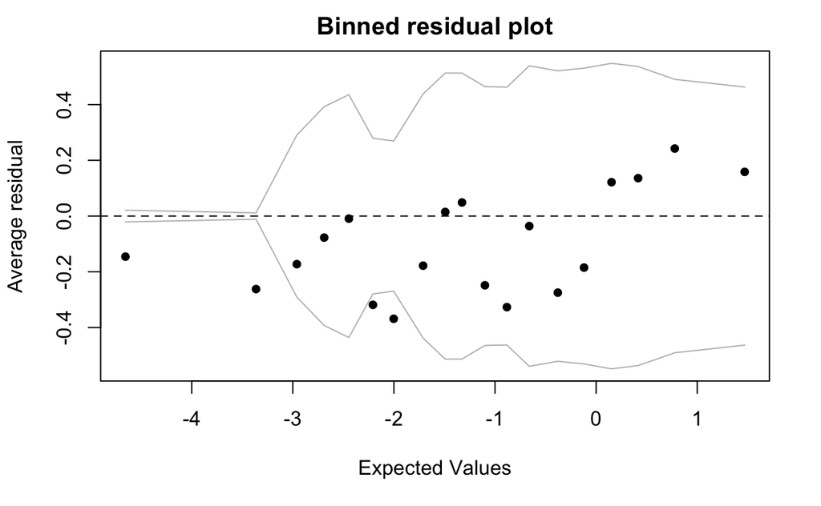

```r
binnedplot(predict(glm_beer_scaled4), resid(glm_beer_scaled4))
```

### Prediction

```r
train_ids <- sample(nrow(beer),round(nrow(beer) * .7))
test_ids <- (1:nrow(beer))[!(1:nrow(beer)) %in% train_ids]
train_beer <- beer %>% slice(train_ids)
test_beer <- beer %>% slice(test_ids)

train_glm <- glm(weekend ~ scaled_consumed, family = binomial, data = train_beer)
ce_error <- mean(round(predict(train_glm, test_beer, type = 'response')) != test_beer$weekend)
```

For this model the classification error is 0.19.